# act_report

## Report: act_report

- Create a **250-word-minimum written report** called "act_report.pdf" or "act_report.html" that communicates the insights and displays the visualization(s) produced from your wrangled data. This is to be framed as an external document, like a blog post or magazine article, for example.

Le compte de Twitter de `WeRateDogs` a gagné de plus en plus de popularité et compte aujourd'hui 9,3 millions d'abonnés, celle ci est du à leur professionalisme au niveau d'attribuer des notes aux chiens et leur système de notes unique qui suppose que tout chien doit être noté à partir de 10/10. Dans cette étude on s'interésse donc aux tweets qu'ils ont publié entre les années 2015 et 2017 afin de sortir avec des réponses pour les questions suivantes:

1. Est ce qu'il y a une corrélation entre le nombre de likes et les notes ?
2. Est ce que les chiens doggo ont plus de likes que les chiens pupper?
3. Est ce que les Golden retreiver ont plus de likes que les chihuahua?
4. Quel sont les chiens les plus aimé?

#### Est ce qu'il y a une correlation entre le nombre de likes et les notes

Un premier réflexe indique que les chiens dans les tweets qui ont plus de likes devraient avoir les meilleurs notes, on étudie donc la correlation entre les deux variables pour les notes < 20 puisque les données des notes > 20 sont très dispersé:

[figure not shown]

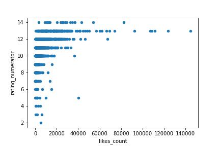

le coefficient de correlation entre les deux variables est 0.42 qui indique qu'il existe une relation linéaire un peu faible entre les deux variables. En effectuant le test de Pearson de correlation on conclut que la correlation entre les deux variables est statistiquement significative.

#### Est ce que les chiens doggo ont plus de likes que les chiens pupper?

Il apparait que la distribution des likes des pupper et doggo sont incliné à gauche ce qui dit que la probabilité d'observer des valeurs très elevés est un peu faible par rapport aux autres valeurs.

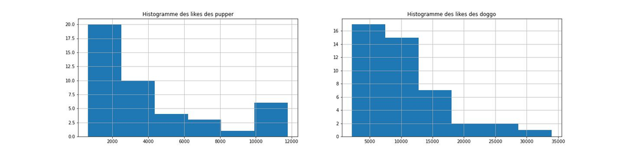

D'après l'echantillon qu'on a on voit que la moyenne des likes des doggo est plus éleve que la moyenne des likes des pupper. Après avoir effectué un test statistique on obtient une p valeur < 0.05 ce qui favorise l'hypothèse que la moyenne des likes des doggo est bien superieur à la moyenne des likes des pupper.

#### Est ce que les Golden retreiver ont plus de likes que les chihuahua?

Voici les histogrammes des distributions des likes des Golden retriever et Chihuahua :

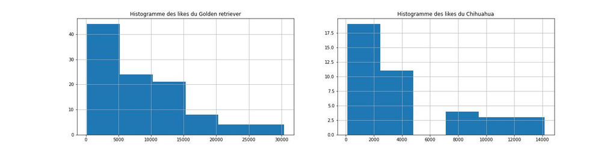

D'après les echantillons qu'on a on remarque que la moyenne des likes des golden retriever est plus elevé que celle des chihuahua. Après avoir effectué un test statistique on s'apperçoit que cette observation est statistiquement significative.

#### Les chiens les plus aimé:

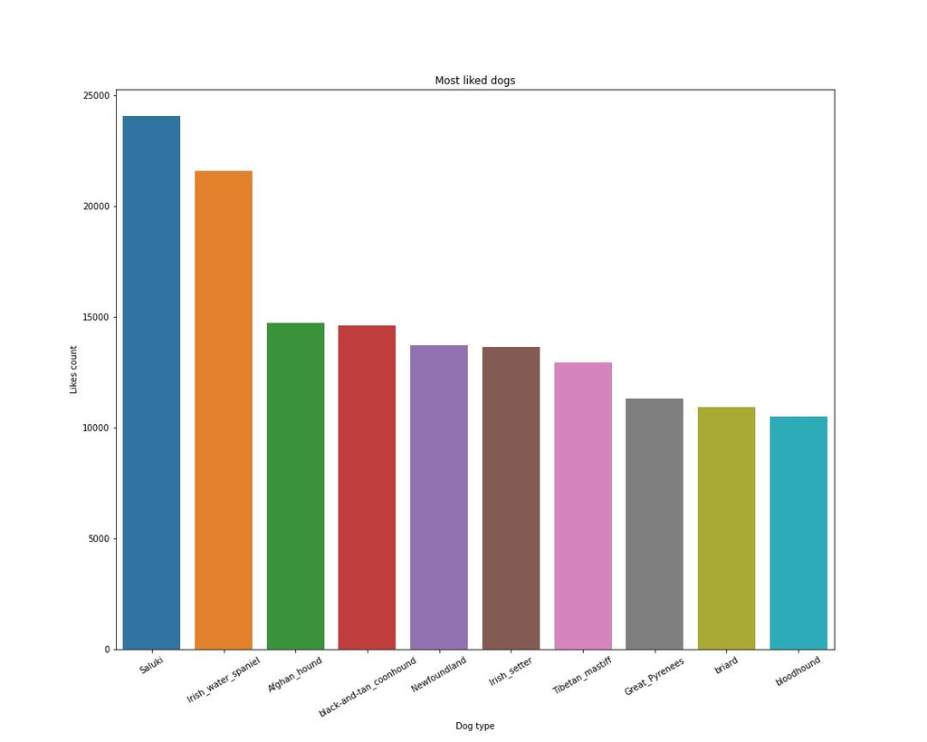

### Conclusion

Pour conclure cette étude voici donc brièvement les réponses aux questions qu'on s'est posé precedement:

- Est ce qu'il y a une corrélation entre le nombre de likes et les notes : On a une correlation mais qui est un peu faible.
- Est ce que les chiens doggo ont plus de likes que les chiens pupper : Oui
- Est ce que les Golden retreiver ont plus de likes que les chihuahua : Oui
- Quel sont les chiens les plus aimé : les tops 3 chiens les plus aimés sont (Saluki - Irish water spaniel - Afghan hound )

A rappeler que dans cette étude la taille de notre de dataset était un peu limité et que les tweets date de l'année 2017, celle ci peut encore être amélioré en rassemblant plus de tweets.